## **R und Big**(ger than memory) **Data**

**Dr. Lars E. Kroll**  
*Fachbereich Data Science und Versorgungsanalysen*

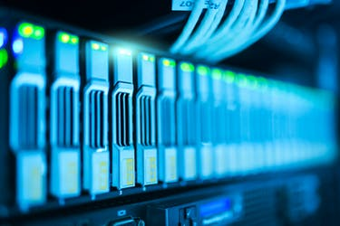

Stand: 17.04.2020

## Hintergrund

## Was ist das Problem?

**R** ist bei kleinen Datensätzen sehr schnell, weil es alle Daten im Arbeitsspeicher des Computers hält.

Dieses Vorgehen wird, wenn große Datensätze (>5GB) analysiert werden sollen, im Vergleich zu Paketen wie *sas* oder *SPSS* problematisch (hier werden die Daten i.d.R. von der Festplatte geladen).

*Ziel:*  
**Diese Präsentation führt in Techniken zur Analyse von großen Datensätzen mit R ein.**

## Technischer Hintergrund

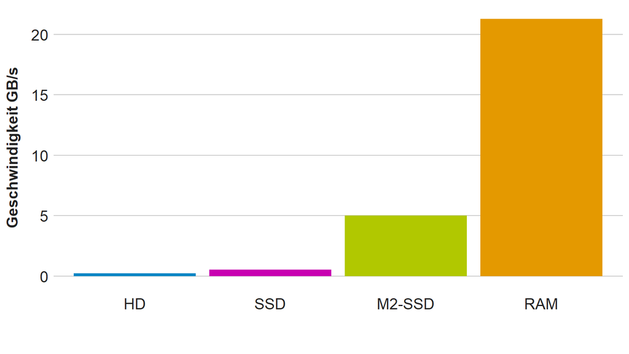

Arbeitsspeicher (RAM) ist *100 mal schneller* als eine klassische Festplatte und *4 mal* schneller als der schnellste M2 PCIE4 SSD Speicher. Je mehr Daten im RAM analysiert werden, desto besser.

## Lösungsansätze

Um große Datensätze mit R zu bearbeiten stehen verschiedene Lösungsansätze zur Verfügung:

**Gute Lösungen** aber heute nicht Thema:

- Mehr RAM kaufen (bis zu 256GB sind aktuell möglich)
- Arbeit mit Zufallsstichproben und verkleinerten Datensätzen

**Heute Thema**

- Arbeiten mit R und `DBI` direkt auf Datenbanken
- Parallelisierung von gestückelten Daten

## Arbeit mit Datenbanken

## R und Datenbanken

Grundsätzlich können Daten, die bereits in einer relationalen oder nicht-relationalen Datenbank vorgehalten werden, immer direkt über geeignete Frontends analysiert werden.

R bietet mit dem Paket DBI aber ebenfalls eine Schnittstelle, um als Frontend einer Datenbank zu fungieren [(mehr Informationen)](https://db.rstudio.com/).

R ist aber auch in der Lage, Datensätze ohne Installation zusätzlicher Software in eine Datenbank auszulagern und auf dieser zu analysieren. Dadurch ist eine Nutzung von R mit Datensätzen möglich, die nicht in den Speicher des lokalen PC passen.

Das Vorgehen soll exemplarisch mit dem Beispieldaten *nycflights13* veranschaulicht werden.

## Testdatensatz *nycflights13*

Der Testdatensatz umfasst 336776 Inlandsflüge, die im Jahr 2013 von den Flughäfen der Stadt New York City in Richtung von Zielen innerhalb der USA gestartet sind.

Als zusätzliche Metadaten sind Informationen zu Airlines, Flughäfen, Wetter und Flugzeugen enthalten.

Der Datensatz passt zwar in der Regel in den Arbeitsspeicher, alle Techniken funktionieren aber auch mit größeren Datensätzen.

## Erzeugen der Testdateien als csv

Hier werden aus dem mitgelieferten Beispieldaten csv Dateien erstellt und gespeichert. In der Realität liegen wahrscheinlich bereits csv-Dateien vor, die bspw. mit dem *SQL Navigator* o.ä. aus einer DB extrahiert wurden.

```r
library(nycflights13)
write.csv(nycflights13::airlines,"data/airlines.csv")
write.csv(nycflights13::flights,"data/flights.csv")
write.csv(nycflights13::airports,"data/airports.csv")
write.csv(nycflights13::planes,"data/planes.csv")
```

## Erzeugen einer Datenbank aus den Testdateien

Es ist mit R möglich, große csv-Dateien in einer Datenbank zu speichern, ohne sie vorher in den Arbeitsspeicher zu laden.

```r
# Create an empty DB
library("RSQLite")
mylocaldb <- dbConnect(RSQLite::SQLite(), "data/mylocaldb.sqlite")
for (myname in c("flights","airlines","airports","planes")) {
dbWriteTable(conn = mylocaldb, name = myname,
             value = paste0("data/",myname,".csv"),
             row.names = FALSE, header = TRUE, overwrite=TRUE)
}
```

Tabellen mit R verknüpfen:

```r
flights <- tbl(mylocaldb,"flights")
planes <- tbl(mylocaldb,"planes")
airports <- tbl(mylocaldb,"airports")
```

## Was sind die 4 Flugzeuge mit den meisten Starts in NYC 2013?

```r
flights %>% count(tailnum) %>% arrange(-n) %>% filter(tailnum!="NA") %>%
  head(4) %>% left_join(planes,by="tailnum") %>%
  mutate(model=paste(manufacturer,model)) %>%
  select(Kennung=tailnum,"Starts"=n,Modell=model,Baujahr=year) %>%
  mykable()
```

| Kennung | Starts | Modell | Baujahr |
| --- | --- | --- | --- |
| “N725MQ” | 575 |  |  |
| “N722MQ” | 513 |  |  |
| “N723MQ” | 507 |  |  |
| “N711MQ” | 486 | “GULFSTREAM AEROSPACE” “G1159B” | 1.976 |

## Inlands-Flugziele von NYC mit mehr als 2500 Flügen 2013

1. Schritt: Flugrouten auszählen

```r
allflights <- flights %>% group_by(origin,dest) %>% count() %>%
  ungroup() %>%  mutate(id=row_number())
plotdata <- bind_rows(
  allflights %>% select(id,n,faa=origin) %>% left_join(.,
      airports %>% select(faa,lat,lon)) %>%
    collect() %>% mutate(type="origin"),allflights %>%
    select(id,n,faa=dest) %>% left_join(.,airports %>%
      select(faa,lat,lon)) %>% collect() %>% mutate(type="destination"))
```

2. Schritt: Geodaten laden und Ergebnisdatensatz erstellen

```r
library("sf")
library("rnaturalearth")
world <- ne_countries(scale = "medium", returnclass = "sf")
connections_sf <- plotdata %>% filter(!is.na(lat)) %>%
  st_as_sf(coords = c("lon", "lat"), crs = 4326, agr = "constant") %>%
  group_by(id) %>%  summarise(do_union = FALSE) %>%
  st_cast("LINESTRING") %>% left_join(plotdata %>% select(id,n))
```

3. Schritt: Ergebnis mit ggplot und Hintergrundkarte plotten

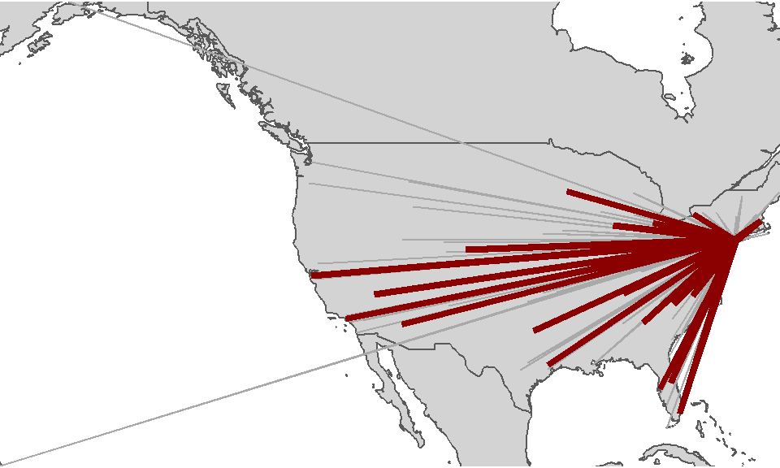

```r
ggplot(connections_sf) + theme_void() +
  geom_sf(data=world,fill="lightgrey") +
  geom_sf(data=.%>% filter(n<=2500),
          show.legend = F,color="darkgrey")+
  geom_sf(data=.%>% filter(n>2500),
          show.legend = F,color="darkred",size=1.5) +
  coord_sf(expand=FALSE,
           xlim =c(st_bbox(connections_sf)[1],st_bbox(connections_sf)[3]),
           ylim=c(st_bbox(connections_sf)[2],st_bbox(connections_sf)[4]))
```

## Regressionsanalyse

**Fragestellung:**  
*Ist ein Flug von NYC umso pünktlicher, je weiter sein Ziel entfernt ist?*

Es gibt verschiedene Pakete. Wir haben uns für das Paket *biglm* entschieden, dass die Daten Stückweise in den Arbeitsspeicher des PCs lädt.

Es gibt auch Ansätze, Modelle direkt auf Datenbanken zu rechnen. Hier werden alle Arbeitsschritte in SQL übersetzt und anschließend auf dem Backend ausgeführt. Dies ist bisher aber nur für wenige Modelle sinnvoll möglich. Mehr dazu hier: [tidymodels](https://tidymodels.github.io/)

**Ergebnistabelle:**

```r
model <- flights %>% mutate(distance=distance/1000,
         quartal=as.character(floor(month/4)+1)) %>%
  biglm::biglm(dep_delay~1+distance+quartal, data=.)
broom::tidy(model) %>% mykable()
```

| term | estimate | std.error | p.value |
| --- | --- | --- | --- |
| (Intercept) | 12,049 | 0,168 | 0 |
| distance | -1,001 | 0,093 | 0 |
| quartal2.0 | 5,890 | 0,182 | 0 |
| quartal3.0 | -3,288 | 0,182 | 0 |
| quartal4.0 | 4,989 | 0,274 | 0 |

*Ergebnis:*  
*Je weiter das Ziel, desto pünktlicher der Flug. Aber im Winter- und Sommerquartal sind Flüge weniger pünktlich.*

## Geschwindigkeitsvorteile durch die Datenbank?

Nein, die Arbeit mit einer DB als Backend ist **deutlich langsamer** als die Arbeit im Arbeitsspeicher!

```r
flights_ram<- flights %>% collect()
start_time <- Sys.time()
result <- flights_ram %>% group_by(carrier) %>%
  summarise(Mean_delay=mean(sched_dep_time-dep_time,na.rm=T))
end_time <- Sys.time()
t_ram <- round((end_time - start_time)*1000)
```

| Method | Result (msec) |
| --- | --- |
| RAM | 30 |
| SQLITE | 202 |

## Zwischenfazit Datenbanken

- Mit **Datenbanken als Backend für R** lassen sich die meisten deskriptiven Aufgaben bearbeiten.
- Hierbei kann die vielen bekannte *tidyverse* Syntax genutzt werden.
- Es stehen Schnittstellen für die meisten Backends zur Verfügung, mehr dazu [hier](https://db.rstudio.com/).
- Die Nutzung von Datenbanken als Backend bietet gegenüber der Arbeit im Arbeitsspeicher jedoch **Geschwindigkeitsnachteile**.
- Datenbanken sollten für Analysen nur genutzt werden, wenn die Daten nicht in den Arbeitsspeicher passen.

## Arbeit mit “Big Data Lösungen”

## Was machen “Big Data Lösungen” anders?

Das Konzept MapReduce ist die Basis vieler “Big Data Lösungen”

Relationale Datenbanken gehen Tabellen i.d.R. zeilenweise durch, um ein Ergebnis zu generieren.

Demgegenüber setzen Lösungen für verteiltes Rechnen auf Varianten des von Google entwickelten Programmschemas **“MapReduce”**.

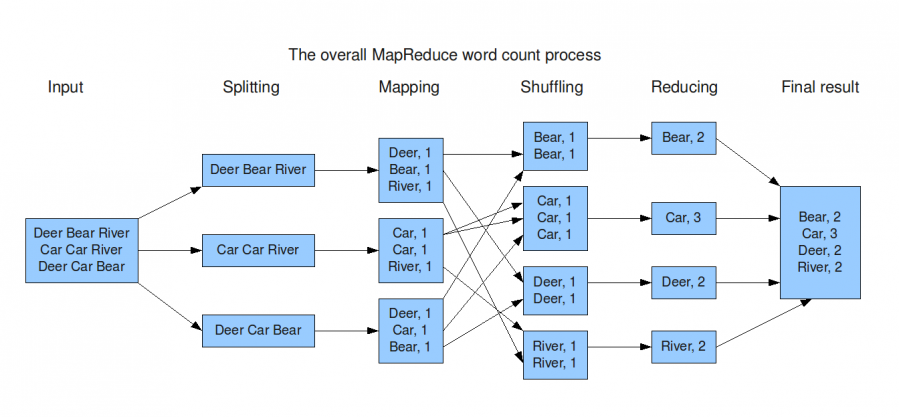

(Quelle: [Groningen 2009](https://blog.trifork.com/2009/08/04/introduction-to-hadoop/))

## Prinzip

Eine *Datenbank* arbeit in der Regel sequentiell und benötigt für **n Zeilen n Arbeitsschritte**, um ein Ergebnis zu generieren.

Ein *verteilter Ansatz* benötigt zwar mehr Schritte (n+m+r mit m:Mapping, r:Reduktion) verteilt diese aber auf mehre Knoten.

Die **Analysezeit** steigt im Fall der *Datenbanken* also proportional zur Anzahl der Zeilen, während sie bei *MapReduce-Ansatz* proportional zur Zahl der Knoten sinkt.

**Je größer n wird, desto mehr Vorteile hat MapReduce gegenüber eine sequentiellen Verarbeitung.**

## Hypothetischer Geschwindigkeitsvergleich

Je höher die Zahl der Knoten, desto größer ist der Overhead durch den Algorithmus, aber auch der potentielle Geschwindigkeitsvorteil bei sehr großen Datenmengen.

| Zeilen | Dauer pro Zeile | Knoten | Overhead | Dauer DB | Dauer MR | Unterschied |
| --- | --- | --- | --- | --- | --- | --- |
| 1.000 | 0,001 | 6 | 1,2 | 1 | 1 | 138 % |
| 10.000 | 0,001 | 6 | 1,2 | 10 | 3 | 29 % |
| 100.000 | 0,001 | 6 | 1,2 | 100 | 18 | 18 % |
| 1.000.000 | 0,001 | 6 | 1,2 | 1.000 | 168 | 17 % |
| 10.000.000 | 0,001 | 6 | 1,2 | 10.000 | 1.668 | 17 % |
| 100.000.000 | 0,001 | 6 | 1,2 | 100.000 | 16.668 | 17 % |
| 1.000.000.000 | 0,001 | 6 | 1,2 | 1.000.000 | 166.668 | 17 % |
| 10.000.000.000 | 0,001 | 6 | 1,2 | 10.000.000 | 1.666.668 | 17 % |

*Annahme:*  
Der Overhead für MapReduce Operationen entspricht etwa 0.1 * (Maps+Reduces) = 0.1 * 2 * Knoten

## Softwarebibliotheken

**Hadoop** verteiltes Dateisystem auf Basis des MapReduce Prinzips, dass nach dem Prinzip eines Festplatten-RAID Systems funktioniert.

**Apache Spark** ist ein Framework für Cluster Computing das auf Hadoop basiert. Es setzt statt auf Festplattenspeicher aber konsequent auf die Analyse der Daten im Arbeitsspeicher.

**CUDA** ist eine vergleichbare Implementierung zum parallelen Ausführung gleichförmiger Aufgaben auf den Kernen von Grafikprozessoren (GPU).

**Disk.Frame** und **dask** sind R (bzw. Python) Bibliotheken, die für die hoch parallelisierte Arbeit auf lokalen Rechnern nutzbar sind.

**Tensorflow GPU**, **RAPIDS** und **BlazingSQL** nutzen GPUs für noch höhere Geschwindigkeiten. Sie sind nur in Python voll implementiert und erfordern teilweise Linux als OS.

## Die Bibliothek **disk.frames** für R

Das Paket **disk.frame** wurde entwickelt, um mit R Daten parallelisiert zur analysieren, die nicht in den Arbeitsspeicher (RAM) passen. Es teilt den Datensatz dazu in Einzeldatensätze auf.

Diese **Einzeldatensätze** werden in einem Ordner gespeichert und können gemeinsam mit R wie ein großer Datensatz analysiert werden.

Der Ansatz von *disk.frame* ähnelt dabei Apache Spark, Dask und ähnlichen Systemen. Er ist besonders **für medium sized data geeignet**, die nicht in den RAM, wohl aber auf die Festplatte passen.

Für medium sized data, ist die Nutzung eines Computer-Clusters nicht nötig, durch disk.frame wird der **Overhead** bei vergleichbarer Performance deutlich reduziert

## Wichtige Konzepte

*disk.frame* nutzt wie die meisten Frameworks für verteilte Analysen die Konzepte **chunks** und **shards** bei der Datenaufteilung (**Partitionierung**). Der Umgang damit ist zentral, für die Performance des Frameworks.

Die **Einzeldatensätze werden als “chunks” bezeichnet**. Sie haben eine feste Größe. Ihre Größe kann entweder durch den Parameter “Anzahl Chunks” oder durch den Parameter *Chunk-Größe* beeinflusst werden.

Falls Partitionen regelhaft vorkommen, bietet es sich an, die Einzeldatensätze in shards aufgrund eines sog. **sharding-keys** zu gruppieren. Dadurch können große Teile der Daten herausgefiltert werde und die Analyse wird beschleunigt.

## **disk.frame** Geschwindigkeitstest

Die chunk-Anzahl entspricht hier der Anzahl der CPUs (max. Performance).

```r
suppressPackageStartupMessages(library(disk.frame))
setup_disk.frame() # 6 Workers
dfflights <- csv_to_disk.frame(
  "data/flights.csv", outdir = "data/tmp_flights.df",  overwrite = T)
```

Die Analyse dauert mit 199 ms zwar länger als im RAM (30 ms), ist aber bereits mit diesem Datensatz, trotz des Overheads durch die Parallelisierung, ebenso schnell wie SQLite (202).

*Hinweis: Die Ergebnisse für disk.frames und SQLite variieren, je nach momentaner Auslastung der Festplatte.*

## Logistische Regression

*Frage: Haben Nachtflüge häufiger >10 Min. Verspätung?*

```r
dfflights <- csv_to_disk.frame("data/flights.csv",
                               outdir = "data/tmp_flights.df",  overwrite = T)
dfflights %>% mutate(delayed=dep_delay>10,
                     distance=distance/1000,
                     nightstart = (dep_time<600) |(dep_time>2000)) %>%
  dfglm(delayed~1+distance+nightstart ,data=., family=binomial()) %>%
  broom::tidy(exponentiate=TRUE,conf.int=TRUE) %>% mykable()
```

| term | estimate | std.error | p.value | conf.low | conf.high |
| --- | --- | --- | --- | --- | --- |
| (Intercept) | 0,296 | 0,007 | 0 | 0,292 | 0,301 |
| distance | 0,958 | 0,006 | 0 | 0,947 | 0,969 |
| nightstartTRUE | 2,957 | 0,011 | 0 | 2,896 | 3,020 |

*Man sollte lieber tagsüber von NYC starten…*